# MIS480 Portfolio Project

Joshua Harris

3/7/2021

## Step 1: Import libraries and dataset

The beginning steps in data analysis is identifying the dataset for the project. The dataset used today will be the **Bank Direct Marketing: An Application of the CRISP-DM Methodology** – obtained from UCI Machine Learning Repository.

Once the file is on the local machine, a few things are done as RStudio is opened.

First, the RStudio software uses libraries that contain tools for data analysis. The libraries will be loaded first – libraries can be added later if it becomes necessary.

Second, RStudio will need to know where to find and save files. A working directory is created and this will contain the bank dataset from UCI. This will also save the R coding as the project grows.

Third, the file is loaded into the RStudio program through the `read.csv` function. The file is saved as a variable named `bank_full`.

Lastly, two variables are created to document the number of rows and columns in the dataset. This step is not a requirement however it will allow for dynamic programming later in this presentation.

```r
library(tidyverse)
library(ggplot2)
library(gridExtra)
library(GGally)
library(pander)
library(caret)
library(rpart)
library(rpart.plot)
library(rminer)
library(nnet)
library(caTools)
library(dummies)
library(Amelia)

set.seed(100)

# Set a working directory
setwd("C:/Users/elksd/Dropbox/My PC (LAPTOP-899T4F9L)/Documents/School Stuff/19 MIS 480/MIS480_Portfolio_Project")

bank_full<-read.csv("bank-full.csv", header = TRUE)

row_count<-nrow(bank_full)
var_count<-ncol(bank_full)
```

The code chunk above indicates our commands were successful. As we move forward, the data will need to presented. The `str(bank_full)` function will present the structure of the dataset.

The structure is a `## 'data.frame'` with 45211 observations on 17 variables. The `row_count` and `var_count` variables, from the previous code chunk, was used to dynamically insert the correct numbers. This is useful when using datasets that may have changing data – this could come into play later in our analysis when we check for duplicate or missing data.

The variable types are listed as either `int` and `chr` (an `int` is an integer and a `chr` is a character.

```
## 'data.frame':    45211 obs. of  17 variables:
##  $ age      : int  58 44 33 47 33 35 28 42 58 43 ...
##  $ job      : chr  "management" "technician" "entrepreneur" "blue-collar" ...
##  $ marital  : chr  "married" "single" "married" "married" ...
##  $ education: chr  "tertiary" "secondary" "secondary" "unknown" ...
##  $ default  : chr  "no" "no" "no" "no" ...
##  $ balance  : int  2143 29 2 1506 1 231 447 2 121 593 ...
##  $ housing  : chr  "yes" "yes" "yes" "yes" ...
##  $ loan     : chr  "no" "no" "yes" "no" ...
##  $ contact  : chr  "unknown" "unknown" "unknown" "unknown" ...
##  $ day      : int  5 5 5 5 5 5 5 5 5 5 ...
##  $ month    : chr  "may" "may" "may" "may" ...
##  $ duration : int  261 151 76 92 198 139 217 380 50 55 ...
##  $ campaign : int  1 1 1 1 1 1 1 1 1 1 ...
##  $ pdays    : int  -1 -1 -1 -1 -1 -1 -1 -1 -1 -1 ...
##  $ previous : int  0 0 0 0 0 0 0 0 0 0 ...
##  $ poutcome : chr  "unknown" "unknown" "unknown" "unknown" ...
##  $ y        : chr  "no" "no" "no" "no" ...
```

**Variable information:**

1. `age`
2. `job`
3. `marital`
4. `education`
5. `default`: is credit in default?
6. `balance`: avg yearly balance
7. `housing`: has a home loan?
8. `loan`: has a personal loan?
9. `contact`: Cellular, Telephone, Unknown
10. `day`: last contact day of the month
11. `month`: last contact month of the year
12. `duration`: last contact duration, in seconds
13. `campaign`: number of contacts performed during this campaign
14. `pdays`: number of days that passed by after the client was last contacted from a previous campaign, -1 means client was not previously contacted
15. `previous`: number of contacts performed before this campaign and for this client.
16. `poutcome`: outcome of the previous marketing campaign
17. `y`: **OUTPUT VARIABLE** -> has the client purchased a term deposit?

There are several variables categorized as a character but this will not work for our analysis. As the data analysis moves forward, the **chr** variable types will need to be converted to a factor type.

## Step 2: Begin to manipulate the data

This section changes 11 variables to new data types – factors. This change will allow for categorical analysis. This change creates the categories so they can aggregate the data into sum totals. The code chunk below demonstrates how RStudio will change variable types.

```r
# Change int to factor
bank_full$job<-as.factor(bank_full$job)
bank_full$marital <-as.factor(bank_full$marital)
bank_full$education <-as.factor(bank_full$education)
bank_full$default <-as.factor(bank_full$default)
bank_full$housing <-as.factor(bank_full$housing)
bank_full$loan <-as.factor(bank_full$loan)
bank_full$contact <-as.factor(bank_full$contact)
bank_full$day<-as.factor(bank_full$day)
bank_full$month <-as.factor(bank_full$month)
bank_full$poutcome <-as.factor(bank_full$poutcome)
bank_full$y <-as.factor(bank_full$y)
```

The new structure of data is below and the `as.factor` function performed as expected – specified `chr` data types are now `Factor` data types.

```
## 'data.frame':    45211 obs. of  17 variables:
##  $ age      : int  58 44 33 47 33 35 28 42 58 43 ...
##  $ job      : Factor w/ 12 levels "admin.","blue-collar",..: 5 10 3 2 12 5 5 3 6 10 ...
##  $ marital  : Factor w/ 3 levels "divorced","married",..: 2 3 2 2 3 2 3 1 2 3 ...
##  $ education: Factor w/ 4 levels "primary","secondary",..: 3 2 2 4 4 3 3 3 1 2 ...
##  $ default  : Factor w/ 2 levels "no","yes": 1 1 1 1 1 1 1 2 1 1 ...
##  $ balance  : int  2143 29 2 1506 1 231 447 2 121 593 ...
##  $ housing  : Factor w/ 2 levels "no","yes": 2 2 2 2 1 2 2 2 2 2 ...
##  $ loan     : Factor w/ 2 levels "no","yes": 1 1 2 1 1 1 2 1 1 1 ...
##  $ contact  : Factor w/ 3 levels "cellular","telephone",..: 3 3 3 3 3 3 3 3 3 3 ...
##  $ day      : Factor w/ 31 levels "1","2","3","4",..: 5 5 5 5 5 5 5 5 5 5 ...
##  $ month    : Factor w/ 12 levels "apr","aug","dec",..: 9 9 9 9 9 9 9 9 9 9 ...
##  $ duration : int  261 151 76 92 198 139 217 380 50 55 ...
##  $ campaign : int  1 1 1 1 1 1 1 1 1 1 ...
##  $ pdays    : int  -1 -1 -1 -1 -1 -1 -1 -1 -1 -1 ...
##  $ previous : int  0 0 0 0 0 0 0 0 0 0 ...
##  $ poutcome : Factor w/ 4 levels "failure","other",..: 4 4 4 4 4 4 4 4 4 4 ...
##  $ y        : Factor w/ 2 levels "no","yes": 1 1 1 1 1 1 1 1 1 1 ...
```

In the summary window below, there are a few items to note.

There are several categories with a high number of **other** – `job`, `day`, and `month`. In this situation, `day` will be changed back to an `int` data type but `job` and `month` will stay as a factor.

There are several categories with a high number of **unknown** – `education`, `contact`, and `poutcome`. This does not warrant any changes now but it will be useful to be aware of while we continue with the analysis.

```
##       age                 job           marital          education
##  Min.   :18.00   blue-collar:9732   divorced: 5207   primary  : 6851
##  1st Qu.:33.00   management :9458   married :27214   secondary:23202
##  Median :39.00   technician :7597   single  :12790   tertiary :13301
##  Mean   :40.94   admin.     :5171                    unknown  : 1857
##  3rd Qu.:48.00   services   :4154
##  Max.   :95.00   retired    :2264
##                  (Other)    :6835
##  default        balance       housing      loan            contact
##  no :44396   Min.   : -8019   no :20081   no :37967   cellular :29285
##  yes:  815   1st Qu.:    72   yes:25130   yes: 7244   telephone: 2906
##              Median :   448                           unknown  :13020
##              Mean   :  1362
##              3rd Qu.:  1428
##              Max.   :102127
##
##       day            month          duration         campaign
##  20     : 2752   may    :13766   Min.   :   0.0   Min.   : 1.000
##  18     : 2308   jul    : 6895   1st Qu.: 103.0   1st Qu.: 1.000
##  21     : 2026   aug    : 6247   Median : 180.0   Median : 2.000
##  17     : 1939   jun    : 5341   Mean   : 258.2   Mean   : 2.764
##  6      : 1932   nov    : 3970   3rd Qu.: 319.0   3rd Qu.: 3.000
##  5      : 1910   apr    : 2932   Max.   :4918.0   Max.   :63.000
##  (Other):32344   (Other): 6060
##      pdays          previous           poutcome       y
##  Min.   : -1.0   Min.   :  0.0000   failure: 4901   no :39922
##  1st Qu.: -1.0   1st Qu.:  0.0000   other  : 1840   yes: 5289
##  Median : -1.0   Median :  0.0000   success: 1511
##  Mean   : 40.2   Mean   :  0.5803   unknown:36959
##  3rd Qu.: -1.0   3rd Qu.:  0.0000
##  Max.   :871.0   Max.   :275.0000
##
```

The `$ day` variable is changed back to an **int** variable type. The follow code: `bank_full$day<-as.integer(bank_full$day)` is used to change a variable type from factor to an integer.

```
## 'data.frame':    45211 obs. of  17 variables:
##  $ age      : int  58 44 33 47 33 35 28 42 58 43 ...
##  $ job      : Factor w/ 12 levels "admin.","blue-collar",..: 5 10 3 2 12 5 5 3 6 10 ...
##  $ marital  : Factor w/ 3 levels "divorced","married",..: 2 3 2 2 3 2 3 1 2 3 ...
##  $ education: Factor w/ 4 levels "primary","secondary",..: 3 2 2 4 4 3 3 3 1 2 ...
##  $ default  : Factor w/ 2 levels "no","yes": 1 1 1 1 1 1 1 2 1 1 ...
##  $ balance  : int  2143 29 2 1506 1 231 447 2 121 593 ...
##  $ housing  : Factor w/ 2 levels "no","yes": 2 2 2 2 1 2 2 2 2 2 ...
##  $ loan     : Factor w/ 2 levels "no","yes": 1 1 2 1 1 1 2 1 1 1 ...
##  $ contact  : Factor w/ 3 levels "cellular","telephone",..: 3 3 3 3 3 3 3 3 3 3 ...
##  $ day      : int  5 5 5 5 5 5 5 5 5 5 ...
##  $ month    : Factor w/ 12 levels "apr","aug","dec",..: 9 9 9 9 9 9 9 9 9 9 ...
##  $ duration : int  261 151 76 92 198 139 217 380 50 55 ...
##  $ campaign : int  1 1 1 1 1 1 1 1 1 1 ...
##  $ pdays    : int  -1 -1 -1 -1 -1 -1 -1 -1 -1 -1 ...
##  $ previous : int  0 0 0 0 0 0 0 0 0 0 ...
##  $ poutcome : Factor w/ 4 levels "failure","other",..: 4 4 4 4 4 4 4 4 4 4 ...
##  $ y        : Factor w/ 2 levels "no","yes": 1 1 1 1 1 1 1 1 1 1 ...
```

The next steps will look for any missing or duplicate data elements. The outcome reflects no missing data – the dataset is validated and ready for for further analysis.

```r
# Data validation
sum(duplicated(bank_full))
```

```
## [1] 0
```

```r
sum(!complete.cases(bank_full))
```

```
## [1] 0
```

## Step 3: Disecting and visualizing data

The first order of business is learning more about the data. So far, we have looked at the structure of data and identified the number of rows (45211) and columns (17). We have identified which data types will be integers and factors and the summary statistics for them.

The first two graphs shows age information about the client list. The average age of the client is 41 – rounded to the lowest integer. The box plot graph shows some outliers in the older age group area – approx. > 70 years old.

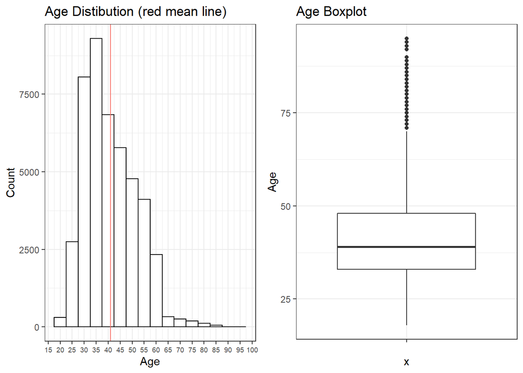

Below is a table display of the `age` variable summary statistics.

| Min. | 1st Qu. | Median | Mean | 3rd Qu. | Max. |
| --- | --- | --- | --- | --- | --- |
| 18 | 33 | 39 | 40.94 | 48 | 95 |

Now that the age analysis is done, we can visually see the general age target of the customer – approx. 25 to 60 years old. Next, the interest shifts to how many customer said yes or no to a term deposit.

The probability outcome:

**5289** clients said yes to a term deposit – or **11.70%**

**39922** clients said no to a term deposit – or **88.30%**

The two tables below represent the findings.

| no | yes |
| --- | --- |
| 39922 | 5289 |

| no | yes |
| --- | --- |
| 0.883 | 0.117 |

As we move on, we want to see how the “yes” and “no” clients are distributed throughout other categories. The graph below is used to differentiate the yes/no variable against the age variable.

The graph has some adjustments to better show the data. The ggplot library offers some options that make some quick and easy visual manipulations into better graphics.

Here the colors are dimmed for better aesthetics. In addition, the points are spread a apart with the `position_jitter` function.

This begins the process of better visualizations on the data.

The code behind the graph is displayed here to demonstrate how it was built.

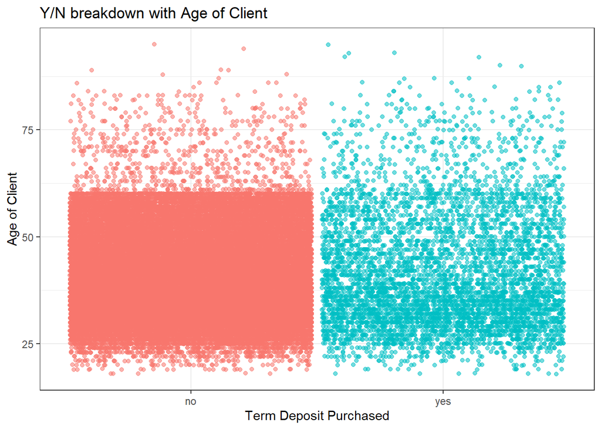

```r
bank_full %>%
  ggplot(aes(x = y, y = age, color = y, alpha = 0.01))+
  geom_point(position = position_jitter(width = 0.48, height = 0.1))+
  xlab("Term Deposit Purchased")+
  ylab("Age of Client")+
  ggtitle("Y/N breakdown with Age of Client")+
  theme_bw()+
  theme(legend.position = "none")
```

This graph is plotting age against job with the y outcome determining the color. The visualization is interesting.

First, the retired category is shifted appropriately to later years of life.

Second, the unknown category again shows high levels of nos – minimizing the unknown category should be a priority going forward.

Third, students appear to be a small quantity category but it has high levels of yes vs no.

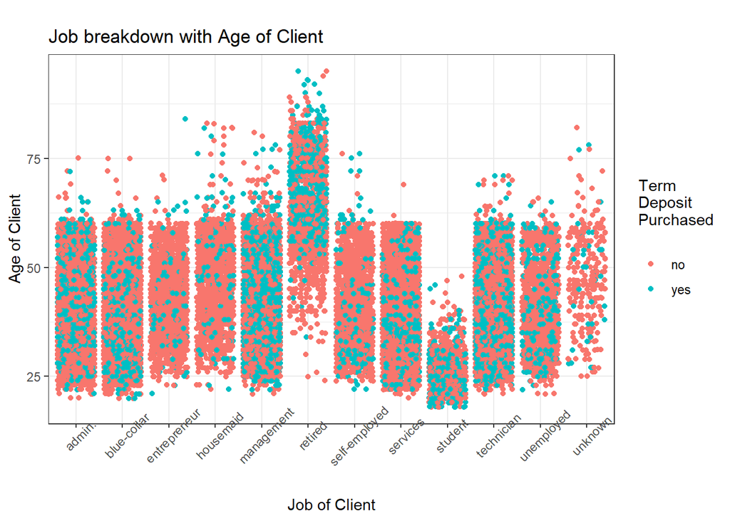

Let’s look at marital status. The married clients seem to have more yes responses compared to the other two categories. However the shift in the age of the graph is interesting. There is normally distinct line around 60 years of age but the married group goes well into 70s.

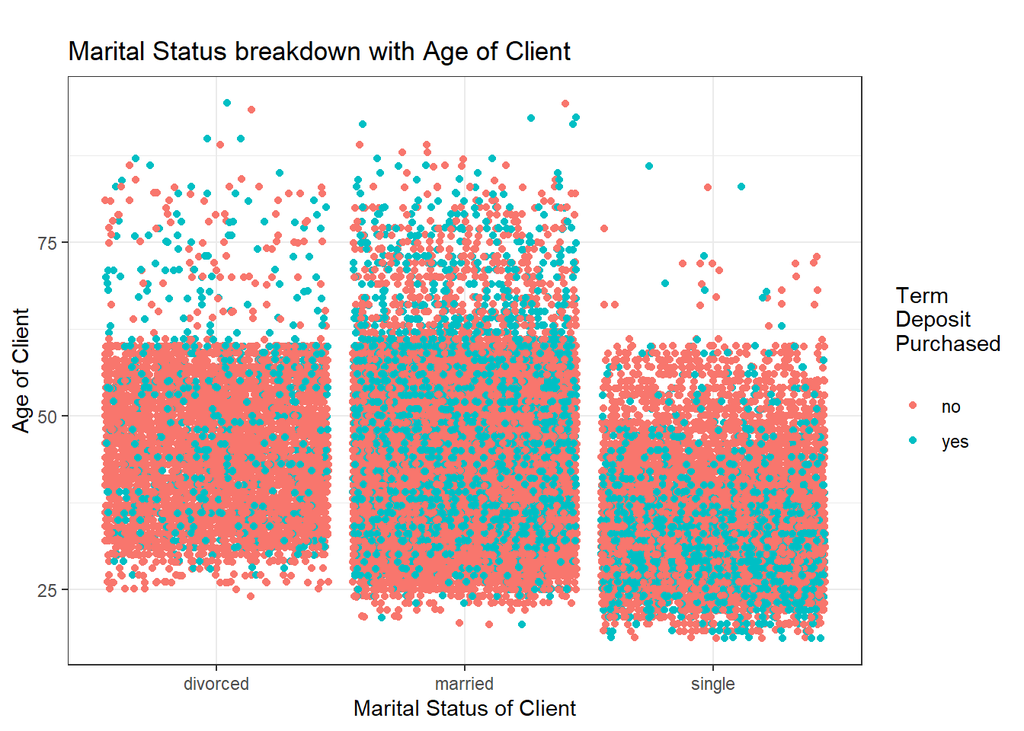

Here I will do some grouping and plotting to look at the outcome. This graph is plotting education on the x-axis, the age on the y-axis and the color is set to y which is the yes outcome.

This image shows more yeses in the secondary and tertiary columns compared to the primary and unknown. Also, the unknown category outcome has a high number of nos. Does this mean avoiding an unknown educational background is important–more analysis is needed.

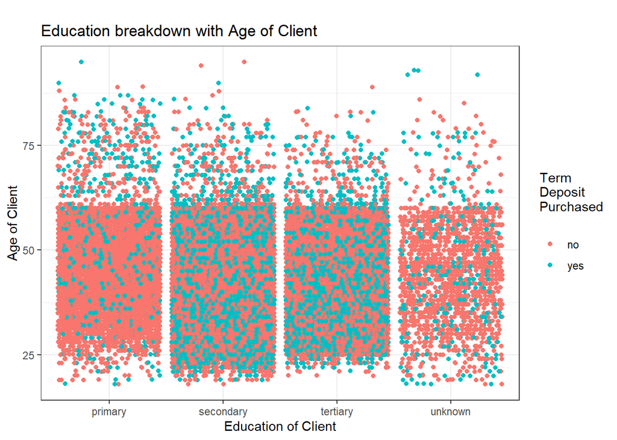

Default category represents clients with credit in default. This graph shows a smaller amount of data points in the yes area. This is likely a good sign being the clients in the yes category are in a bad status with the bank.

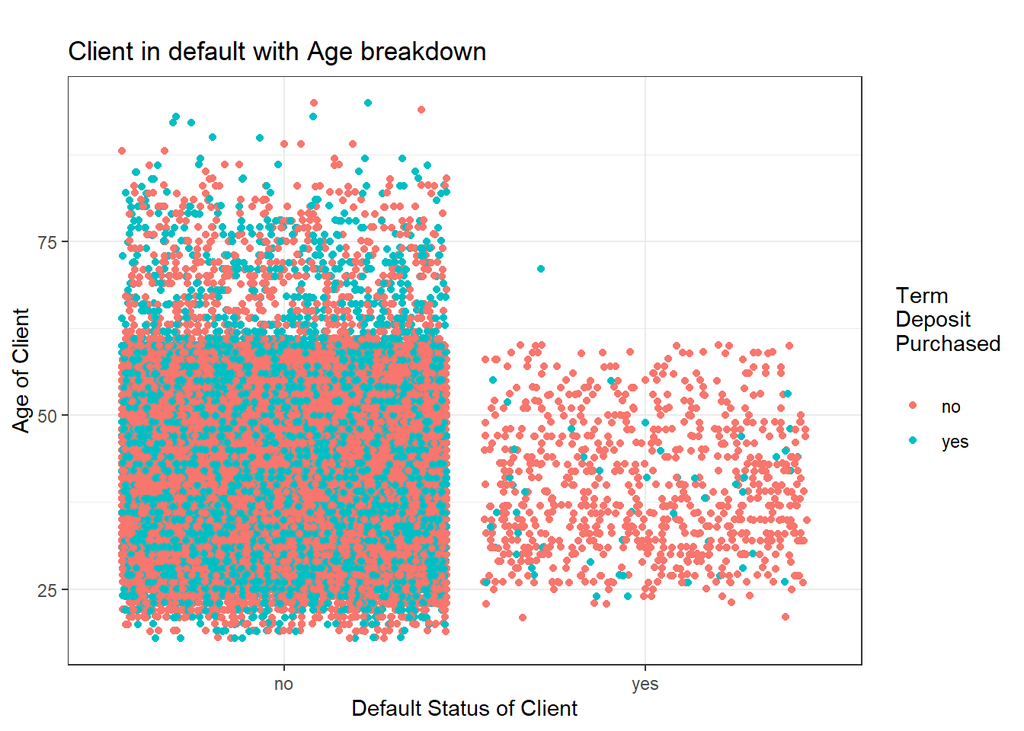

The housing category shows more yeses in the no side of the graph. It also shows more contacts after the age of 60 compared to the yes side. This could be due to a perceived lack of dispospable income.

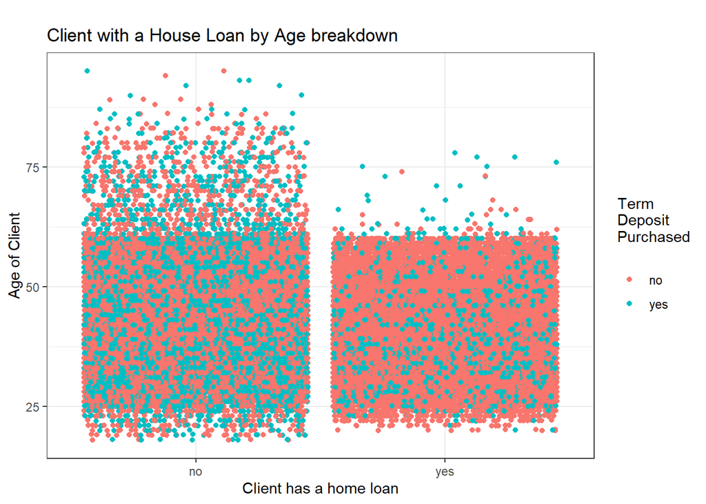

The loan category is similar to the house category. There are more yeses on the no side and more contacts after 60.

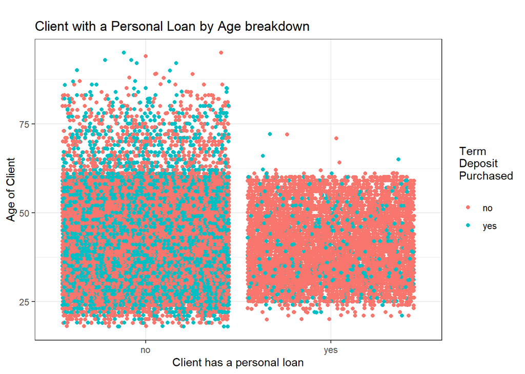

The contact category shows some interesting patterns. There are more yeses in cellular. Both celluar and telephone has more data points above 60 compared to unknown leading me to believe many of these could be a work phone number – people retire around this time.

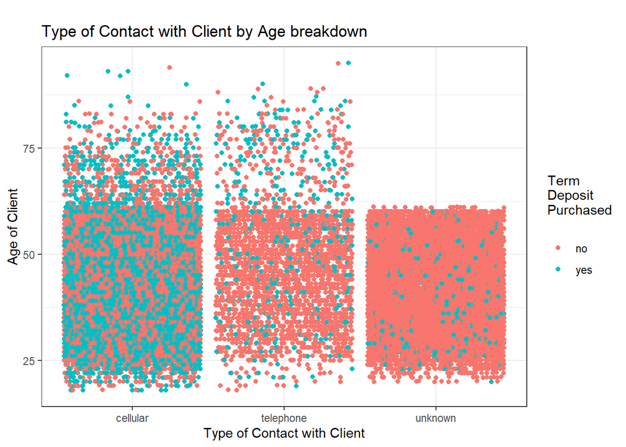

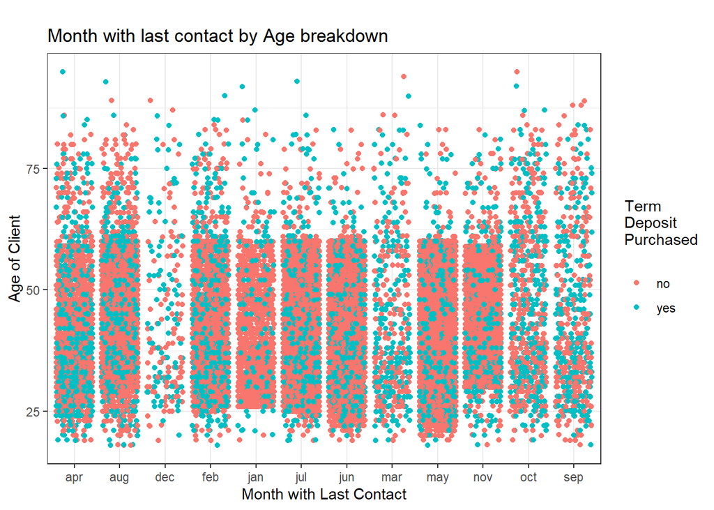

The poutcome graph has a lot of yeses in the success category. This variable could be an important factor in future campaigns. The models will guide us to this conclusion.

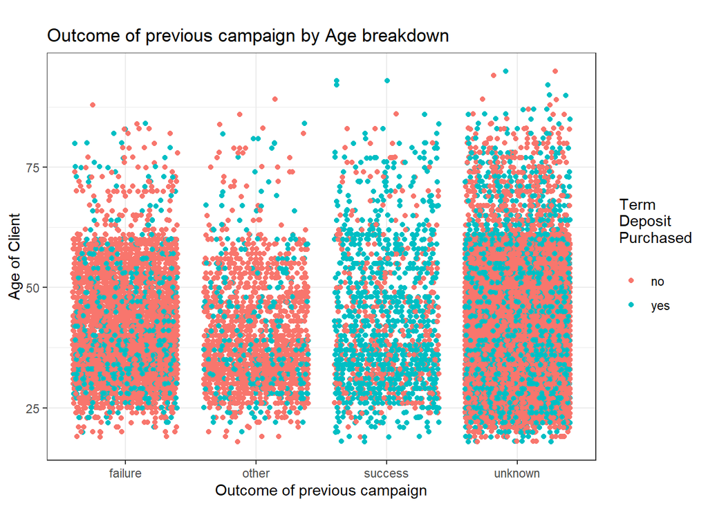

This is the last graph before models are run. The graph is shifted to display Age on the x-axis and show the duration on the y-axis.

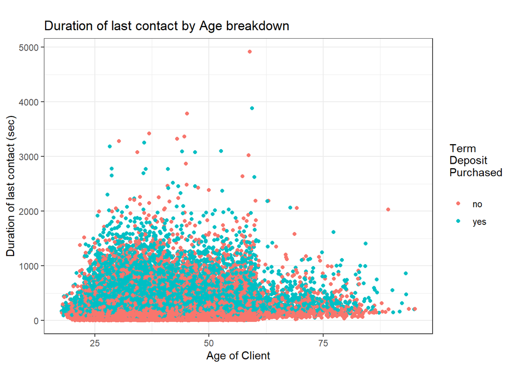

## Modeling - Logistic Regression

This begins the modeling process. The first model is logistic regression.

```
##
## Call:
## glm(formula = y ~ ., family = "binomial", data = bank_train)
##
## Deviance Residuals:
##     Min       1Q   Median       3Q      Max
## -5.0009  -0.3747  -0.2527  -0.1532   3.3280
##
## Coefficients:
##                      Estimate Std. Error z value Pr(>|z|)
## (Intercept)        -2.631e+00  2.113e-01 -12.456  < 2e-16 ***
## age                 2.966e-03  2.536e-03   1.169 0.242278
## jobblue-collar     -3.151e-01  8.396e-02  -3.752 0.000175 ***
## jobentrepreneur    -3.184e-01  1.416e-01  -2.249 0.024481 *
## jobhousemaid       -6.169e-01  1.593e-01  -3.871 0.000108 ***
## jobmanagement      -1.395e-01  8.444e-02  -1.652 0.098446 .
## jobretired          1.795e-01  1.118e-01   1.606 0.108364
## jobself-employed   -3.557e-01  1.316e-01  -2.704 0.006850 **
## jobservices        -2.352e-01  9.643e-02  -2.439 0.014723 *
## jobstudent          3.819e-01  1.266e-01   3.016 0.002560 **
## jobtechnician      -1.907e-01  7.965e-02  -2.394 0.016675 *
## jobunemployed      -1.596e-01  1.291e-01  -1.236 0.216625
## jobunknown         -4.713e-01  2.744e-01  -1.718 0.085861 .
## maritalmarried     -1.855e-01  6.763e-02  -2.742 0.006099 **
## maritalsingle       1.171e-01  7.713e-02   1.518 0.128915
## educationsecondary  1.946e-01  7.488e-02   2.599 0.009362 **
## educationtertiary   3.833e-01  8.697e-02   4.407 1.05e-05 ***
## educationunknown    2.532e-01  1.196e-01   2.118 0.034213 *
## defaultyes          5.105e-02  1.796e-01   0.284 0.776220
## balance             1.300e-05  6.148e-06   2.115 0.034422 *
## housingyes         -6.681e-01  5.055e-02 -13.217  < 2e-16 ***
## loanyes            -4.335e-01  6.927e-02  -6.258 3.90e-10 ***
## contacttelephone   -9.234e-02  8.584e-02  -1.076 0.282069
## contactunknown     -1.567e+00  8.331e-02 -18.811  < 2e-16 ***
## day                 9.644e-03  2.867e-03   3.364 0.000769 ***
## monthaug           -7.365e-01  9.059e-02  -8.130 4.29e-16 ***
## monthdec            5.508e-01  2.069e-01   2.663 0.007750 **
## monthfeb           -1.660e-01  1.029e-01  -1.613 0.106732
## monthjan           -1.296e+00  1.396e-01  -9.283  < 2e-16 ***
## monthjul           -9.139e-01  8.988e-02 -10.168  < 2e-16 ***
```

[output cut: 8 more lines]

```
## pdays              -3.674e-04  3.566e-04  -1.030 0.302867
## previous            8.901e-03  6.575e-03   1.354 0.175791
## poutcomeother       1.799e-01  1.038e-01   1.733 0.083066 .
## poutcomesuccess     2.344e+00  9.585e-02  24.453  < 2e-16 ***
## poutcomeunknown    -1.128e-01  1.073e-01  -1.051 0.293199
## ---
## Signif. codes:  0 '***' 0.001 '**' 0.01 '*' 0.05 '.' 0.1 ' ' 1
##
## (Dispersion parameter for binomial family taken to be 1)
##
##     Null deviance: 24664  on 33908  degrees of freedom
## Residual deviance: 16245  on 33866  degrees of freedom
## AIC: 16331
##
## Number of Fisher Scoring iterations: 6
```

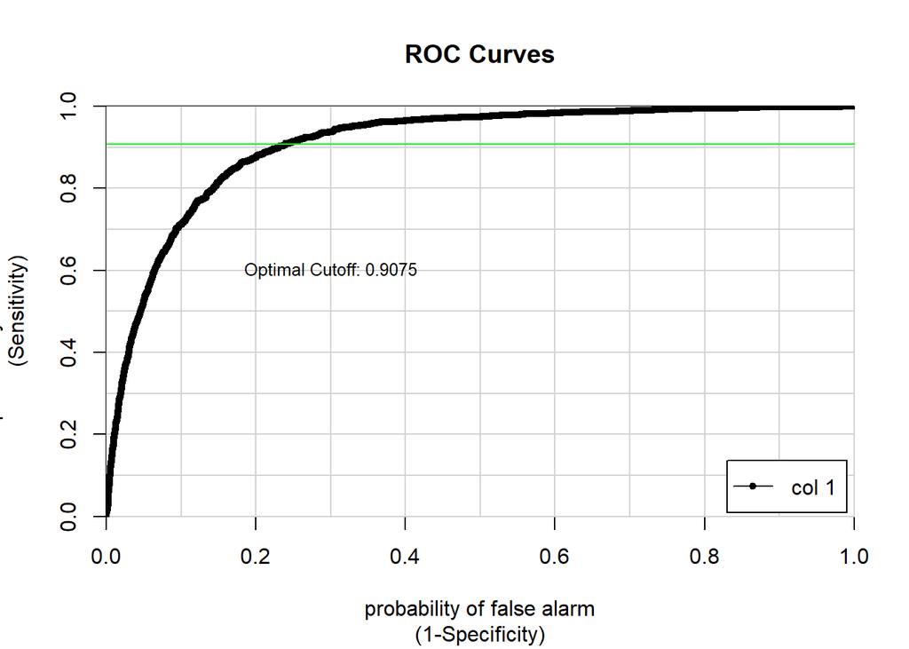

```
## Confusion Matrix and Statistics
##
##           Reference
## Prediction    0    1
##          0 9983 1165
##          1   44  110
##
##                Accuracy : 0.893
##                  95% CI : (0.8872, 0.8987)
##     No Information Rate : 0.8872
##     P-Value [Acc > NIR] : 0.02508
##
##                   Kappa : 0.1329
##
##  Mcnemar's Test P-Value : < 2e-16
##
##             Sensitivity : 0.99561
##             Specificity : 0.08627
##          Pos Pred Value : 0.89550
##          Neg Pred Value : 0.71429
##              Prevalence : 0.88719
##          Detection Rate : 0.88329
##    Detection Prevalence : 0.98637
##       Balanced Accuracy : 0.54094
##
##        'Positive' Class : 0
##
```

## Modeling - Neural Network

This begins the modeling process. The second model is Neural Network.

```
## Call:
## multinom(formula = y ~ ., data = bank_train)
##
## Coefficients:
##                           Values    Std. Err.
## (Intercept)        -2.631344e+00 8.087364e-03
## age                 2.965663e-03 1.163931e-03
## jobblue-collar     -3.150579e-01 7.636936e-03
## jobentrepreneur    -3.184454e-01 3.735362e-04
## jobhousemaid       -6.168942e-01 8.044669e-04
## jobmanagement      -1.395319e-01 1.464068e-02
## jobretired          1.795015e-01 5.300660e-03
## jobself-employed   -3.557403e-01 4.877418e-04
## jobservices        -2.352195e-01 2.688717e-03
## jobstudent          3.819416e-01 2.968570e-03
## jobtechnician      -1.906710e-01 4.149578e-03
## jobunemployed      -1.595618e-01 8.609188e-04
## jobunknown         -4.712583e-01 2.796874e-04
## maritalmarried     -1.854783e-01 2.104503e-02
## maritalsingle       1.171207e-01 2.304253e-02
## educationsecondary  1.945869e-01 1.842184e-02
## educationtertiary   3.832614e-01 1.924146e-02
## educationunknown    2.532230e-01 9.628442e-04
## defaultyes          5.104619e-02 2.155322e-04
## balance             1.300471e-05 6.064679e-06
## housingyes         -6.681142e-01 2.593330e-02
## loanyes            -4.335055e-01 1.921138e-03
## contacttelephone   -9.233727e-02 2.240027e-03
## contactunknown     -1.567181e+00 6.918057e-03
## day                 9.643325e-03 2.382950e-03
## monthaug           -7.364693e-01 5.369637e-03
## monthdec            5.507947e-01 4.339309e-04
## monthfeb           -1.660061e-01 2.314536e-03
## monthjan           -1.296074e+00 1.239297e-03
## monthjul           -9.139303e-01 1.703990e-03
## monthjun            3.461356e-01 1.312774e-03
## monthmar            1.641200e+00 5.385970e-04
## monthmay           -3.935876e-01 1.550437e-02
## monthnov           -9.037385e-01 7.294143e-04
## monthoct            1.001202e+00 1.151261e-03
## monthsep            8.826405e-01 8.949801e-04
## duration            4.277625e-03 7.223525e-05
## campaign           -8.392852e-02 1.086321e-02
## pdays              -3.673644e-04 1.965867e-04
## previous            8.901642e-03 6.328735e-03
## poutcomeother       1.799081e-01 5.659175e-04
## poutcomesuccess     2.343918e+00 1.785950e-03
## poutcomeunknown    -1.127545e-01 9.551679e-03
##
## Residual Deviance: 16245.18
## AIC: 16331.18
```

```
##
## bank_y_Predict2    0    1
##               0 9755  797
##               1  272  478
```

```
## [1] 0.905415
```

```
## [1] 0.09458503
```

## Modeling - Decision Tree

This begins the modeling process. The last model is a decision tree.

```
## 'data.frame':    45211 obs. of  17 variables:
##  $ age      : int  58 44 33 47 33 35 28 42 58 43 ...
##  $ job      : Factor w/ 12 levels "admin.","blue-collar",..: 5 10 3 2 12 5 5 3 6 10 ...
##  $ marital  : Factor w/ 3 levels "divorced","married",..: 2 3 2 2 3 2 3 1 2 3 ...
##  $ education: Factor w/ 4 levels "primary","secondary",..: 3 2 2 4 4 3 3 3 1 2 ...
##  $ default  : Factor w/ 2 levels "no","yes": 1 1 1 1 1 1 1 2 1 1 ...
##  $ balance  : int  2143 29 2 1506 1 231 447 2 121 593 ...
##  $ housing  : Factor w/ 2 levels "no","yes": 2 2 2 2 1 2 2 2 2 2 ...
##  $ loan     : Factor w/ 2 levels "no","yes": 1 1 2 1 1 1 2 1 1 1 ...
##  $ contact  : Factor w/ 3 levels "cellular","telephone",..: 3 3 3 3 3 3 3 3 3 3 ...
##  $ day      : int  5 5 5 5 5 5 5 5 5 5 ...
##  $ month    : Factor w/ 12 levels "apr","aug","dec",..: 9 9 9 9 9 9 9 9 9 9 ...
##  $ duration : int  261 151 76 92 198 139 217 380 50 55 ...
##  $ campaign : int  1 1 1 1 1 1 1 1 1 1 ...
##  $ pdays    : int  -1 -1 -1 -1 -1 -1 -1 -1 -1 -1 ...
##  $ previous : int  0 0 0 0 0 0 0 0 0 0 ...
##  $ poutcome : Factor w/ 4 levels "failure","other",..: 4 4 4 4 4 4 4 4 4 4 ...
##  $ y        : num  0 0 0 0 0 0 0 0 0 0 ...
```

```
## Call:
## rpart(formula = tree_train$y ~ tree_train$age + tree_train$job +
##     tree_train$marital + tree_train$education + tree_train$default +
##     tree_train$balance + tree_train$housing + tree_train$loan +
##     tree_train$contact + tree_train$day + tree_train$month +
##     tree_train$duration + tree_train$campaign + tree_train$pdays +
##     tree_train$previous + tree_train$poutcome)
##   n= 33826
##
##           CP nsplit rel error    xerror       xstd
## 1 0.04077881      0 1.0000000 1.0000000 0.01487032
## 2 0.02958135      3 0.8776636 0.8794184 0.01405694
## 3 0.01629481      4 0.8480822 0.8480822 0.01383265
## 4 0.01000000      5 0.8317874 0.8342943 0.01373213
##
## Variable importance
## tree_train$duration tree_train$poutcome
##                  63                  37
##
## Node number 1: 33826 observations,    complexity param=0.04077881
##   predicted class=0  expected loss=0.117927  P(node) =1
##     class counts: 29837  3989
##    probabilities: 0.882 0.118
##   left son=2 (30063 obs) right son=3 (3763 obs)
##   Primary splits:
##       tree_train$duration < 521.5   to the left,   improve=893.3620, (0 missing)
##       tree_train$poutcome splits as  LLRL,         improve=649.7512, (0 missing)
##       tree_train$month    splits as  LLRLLLLRLLRR, improve=384.2879, (0 missing)
##       tree_train$pdays    < 8.5     to the left,   improve=196.2492, (0 missing)
##       tree_train$previous < 0.5     to the left,   improve=193.1162, (0 missing)
##
## Node number 2: 30063 observations,    complexity param=0.04077881
##   predicted class=0  expected loss=0.07727106  P(node) =0.8887542
##     class counts: 27740  2323
##    probabilities: 0.923 0.077
##   left son=4 (29072 obs) right son=5 (991 obs)
##   Primary splits:
##       tree_train$poutcome splits as  LLRL,         improve=596.0549, (0 missing)
##       tree_train$month    splits as  LLRLLLLRLLRR, improve=380.0552, (0 missing)
##       tree_train$pdays    < 8.5     to the left,   improve=194.3833, (0 missing)
```

[output cut: 62 more lines]

```
##
## Node number 11: 705 observations
##   predicted class=1  expected loss=0.2524823  P(node) =0.02084196
##     class counts:   178   527
##    probabilities: 0.252 0.748
##
## Node number 12: 2287 observations
##   predicted class=0  expected loss=0.3353739  P(node) =0.06761071
##     class counts:  1520   767
##    probabilities: 0.665 0.335
##
## Node number 13: 109 observations
##   predicted class=1  expected loss=0.2018349  P(node) =0.003222373
##     class counts:    22    87
##    probabilities: 0.202 0.798
```

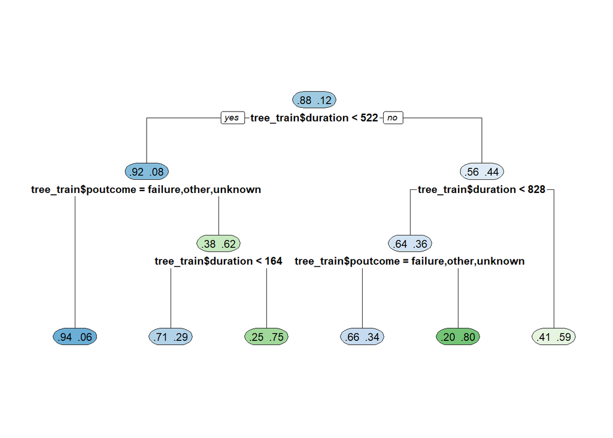

```
## [1] "0" "1"
```

```
## [1] "0" "1"
```

```
## Confusion Matrix and Statistics
##
##           Reference
## Prediction     0     1
##          0 29082  2563
##          1   755  1426
##
##                Accuracy : 0.9019
##                  95% CI : (0.8987, 0.9051)
##     No Information Rate : 0.8821
##     P-Value [Acc > NIR] : < 2.2e-16
##
##                   Kappa : 0.4133
##
##  Mcnemar's Test P-Value : < 2.2e-16
##
##             Sensitivity : 0.9747
##             Specificity : 0.3575
##          Pos Pred Value : 0.9190
##          Neg Pred Value : 0.6538
##              Prevalence : 0.8821
##          Detection Rate : 0.8598
##    Detection Prevalence : 0.9355
##       Balanced Accuracy : 0.6661
##
##        'Positive' Class : 0
##
```

```
## Call:
## rpart(formula = tree_test$y ~ tree_test$age + tree_test$job +
##     tree_test$marital + tree_test$education + tree_test$default +
##     tree_test$balance + tree_test$housing + tree_test$loan +
##     tree_test$contact + tree_test$day + tree_test$month + tree_test$duration +
##     tree_test$campaign + tree_test$pdays + tree_test$previous +
##     tree_test$poutcome)
##   n= 11385
##
##           CP nsplit rel error    xerror       xstd
## 1 0.03057692      0 1.0000000 1.0000000 0.02610356
## 2 0.01769231      4 0.8776923 0.8884615 0.02478101
## 3 0.01000000      5 0.8600000 0.8700000 0.02455094
##
## Variable importance
## tree_test$duration tree_test$poutcome  tree_test$contact    tree_test$month
##                 61                 35                  2                  1
##
## Node number 1: 11385 observations,    complexity param=0.03057692
##   predicted class=0  expected loss=0.1141853  P(node) =1
##     class counts: 10085  1300
##    probabilities: 0.886 0.114
##   left son=2 (9776 obs) right son=3 (1609 obs)
##   Primary splits:
##       tree_test$duration < 451.5 to the left,     improve=273.00910, (0 missing)
##       tree_test$poutcome splits as  LLRL,         improve=229.77220, (0 missing)
##       tree_test$month    splits as  LLRLLLLRLLRR, improve=133.95780, (0 missing)
##       tree_test$pdays    < 32.5  to the left,     improve= 70.52525, (0 missing)
##       tree_test$previous < 0.5   to the left,     improve= 68.19320, (0 missing)
##   Surrogate splits:
##       tree_test$age < 88.5  to the left,  agree=0.859, adj=0.001, (0 split)
##
## Node number 2: 9776 observations,    complexity param=0.03057692
##   predicted class=0  expected loss=0.06976268  P(node) =0.8586737
##     class counts:  9094   682
##    probabilities: 0.930 0.070
##   left son=4 (9481 obs) right son=5 (295 obs)
##   Primary splits:
##       tree_test$poutcome splits as  LLRL,         improve=191.28950, (0 missing)
##       tree_test$month    splits as  LLRLLLLRLLRR, improve=124.59680, (0 missing)
```

[output cut: 67 more lines]

```
##
## Node number 11: 248 observations
##   predicted class=1  expected loss=0.2983871  P(node) =0.02178305
##     class counts:    74   174
##    probabilities: 0.298 0.702
##
## Node number 14: 178 observations
##   predicted class=0  expected loss=0.3651685  P(node) =0.01563461
##     class counts:   113    65
##    probabilities: 0.635 0.365
##
## Node number 15: 480 observations
##   predicted class=1  expected loss=0.4145833  P(node) =0.04216074
##     class counts:   199   281
##    probabilities: 0.415 0.585
```

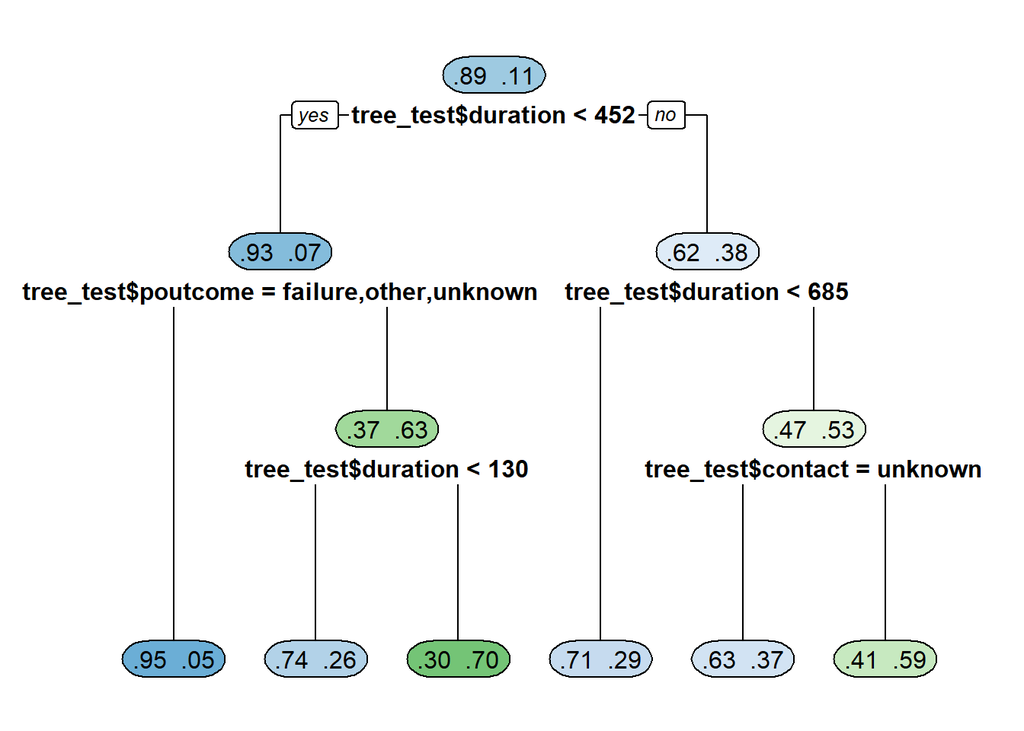

```
## [1] "0" "1"
```

```
## [1] "0" "1"
```

```
## Confusion Matrix and Statistics
##
##           Reference
## Prediction    0    1
##          0 9812  845
##          1  273  455
##
##                Accuracy : 0.9018
##                  95% CI : (0.8962, 0.9072)
##     No Information Rate : 0.8858
##     P-Value [Acc > NIR] : 2.378e-08
##
##                   Kappa : 0.3995
##
##  Mcnemar's Test P-Value : < 2.2e-16
##
##             Sensitivity : 0.9729
##             Specificity : 0.3500
##          Pos Pred Value : 0.9207
##          Neg Pred Value : 0.6250
##              Prevalence : 0.8858
##          Detection Rate : 0.8618
##    Detection Prevalence : 0.9361
##       Balanced Accuracy : 0.6615
##
##        'Positive' Class : 0
##
```